# TIME SERIES TP 1

2020-09-20

```r
library(ggplot2)
library(astsa)
library(dplyr)
library(xts)
```

# 1 EXERCISE 1

## 1.1 Question 1

Ths *ts*($data$, $start$=1, $end$=numeric, $frequency$=1,…) function is used to create a time series object.

- $data$: a vector or matrix of the observed time series
- $start$: the time of the first observation
- $end$: the time of the last observations , specified in the same way as start.
- $frequency$: the numeber of observations par unit of time

The *diff*(data)($x$, $lag$=1) returns suitably and iterated differences

- $x$: a numeric vector or a matrix containing the values to be differenced
- $lag$: an integer indicating which lag to use

## 1.2 Question 2

The *choose.file function choose a file interactively from the current repository.

Not very efficient when we use rmarkdown for a final report.

```r
if(!exists('euro50'))
{
    euro50<-read.csv('tableEurom.csv',header = TRUE)
}
head(euro50)
```

```
        Date    Open    High     Low   Close Volume Adj.Close
1 2015-09-01 3188.73 3198.86 3188.73 3198.86      0   3198.86
2 2015-08-03 3635.40 3676.75 3218.01 3280.78      0   3280.78
3 2015-07-01 3496.28 3686.58 3294.19 3600.69      0   3600.69
4 2015-06-02 3561.89 3583.82 3424.30 3424.30      0   3424.30
5 2015-05-01 3615.59 3632.94 3615.59 3632.94      0   3632.94
6 2015-04-01 3714.89 3828.78 3615.59 3615.59      0   3615.59
```

## 1.3 Question 3

The data contains different informations about a financial index as: the prices at the opening and closing market, the lower and the higher price and so forth.

*euro50[,7]* contains the price at the closing time.

## 1.4 Question 4

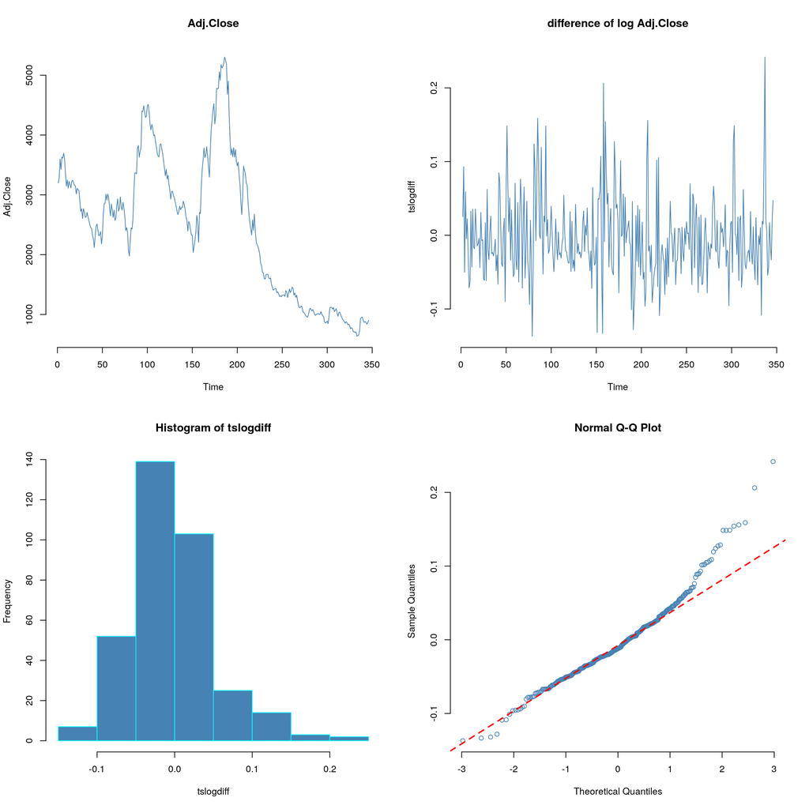

```r
par(mfrow=c(2,2))
tseries50<-ts(euro50)
tslogdiff<-diff(log(tseries50[,7]))
plot(tseries50[,7],
     main='Adj.Close',
     col='steel blue',
     ylab='Adj.Close',
     frame=FALSE
    )
plot(tslogdiff,
     col='steel blue',
     main='difference of log Adj.Close',
     frame=FALSE
     )
hist(tslogdiff,
     col='steel blue',
     border = 'cyan',
     )
qqnorm(tslogdiff,
       col='steel blue',
       frame=FALSE,
       )
qqline(tslogdiff,
       col='red',
       lty=2,
       lwd=2
       )
```

# 2 EXERCISE 2

## 2.1 Question 1

```r
raindata<-read.table('pluie1.txt',
                     sep='',
                     header = TRUE
                     )
head(raindata)
```

```
  annee mois pluie
1  1950    1  16.6
2  1950    2  68.9
3  1950    3  31.8
4  1950    4 107.1
5  1950    5  60.3
6  1950    6 204.8
```

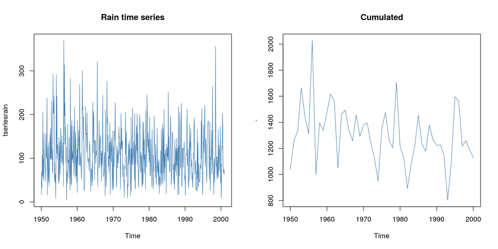

```r
tseriesrain<-ts(raindata$pluie,start = 1950,frequency = 12)
par(mfrow=c(1,2))
plot(tseriesrain,col='steel blue',main='Rain time series')
aggregate(tseriesrain,1,sum)%>%plot(col='steel blue',main='Cumulated')
```

# 3 EXERCISE

## 3.1 Question 1

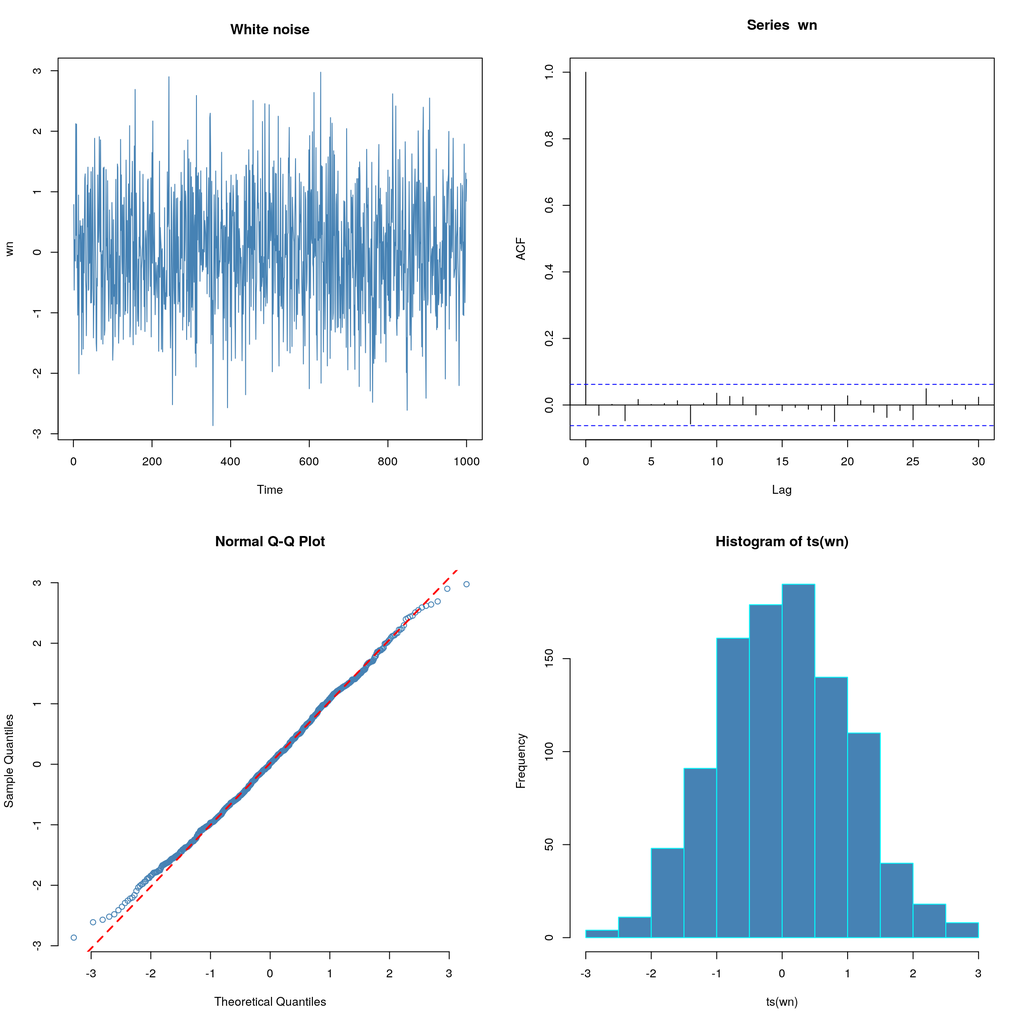

```r
n<-1000
wn<-rnorm(n)
par(mfrow=c(2,2))
plot.ts(wn,col='steel blue',main='White noise')
acf(wn)
qqnorm(ts(wn),
       col='steel blue',
       frame=FALSE,
       )
qqline(ts(wn),
       col='red',
       lty=2,
       lwd=2
       )
hist(ts(wn),col='steel blue',border = 'cyan')
```

## 3.2 Question 2

```r
shapiro.test(ts(wn))
```

```
    Shapiro-Wilk normality test

data:  ts(wn)
W = 0.99798, p-value = 0.2753
```

## 3.3 Question 3

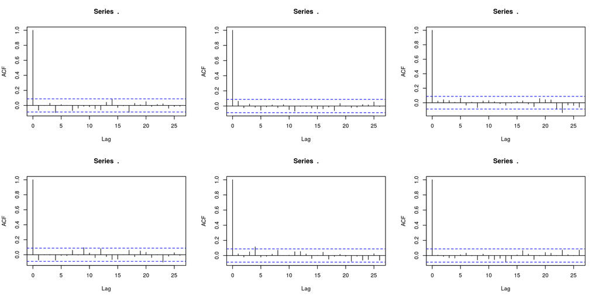

```r
par(mfrow=c(2,3))
for(k in 1:6){rnorm(500)%>%ts()%>%acf()}
```